# Semester Project

Author

# Introduction

The Church of Jesus Christ of Latter-day Saints is a religion that spans the globe. It is a Christian Restoration movement founded in 1830 by a 24 year old named Joseph Smith. With perhaps the most unique beliefs of any mainstream Christian church, it has been the subject of much debate since its conception.

A somewhat unique aspect of this faith is a cultural phenomenon where young men and women serve long term, voluntary teaching or service missions, with their purpose being to invite others to come unto Christ. This typically occurs soon after hey graduate high school.

Surveyed by the Pew Research Center often, a 2011 survey aimed to understand members of this church and how their religion affects their actions and worldview. One of the questions centered around whether or not respondents had served a mission or not. Curious to understand how serving a mission affects other aspects of a Latter-day Saint’s life, I pursued the data to learn more about my faith.

# Design the Study

I am interested to see how having served a mission affects the following topics:

- How much an individual accepts the teachings of the church
- How often and individual prays outside of church
- How often an individual attends church services

Knowing that I approach the subject with bias (I am a returned missionary and active member of the LDS Church), I will use this data to have an informed perspective on the effects of serving a mission. I will systematically take these questions in this order, perform Chi-squared or fisher tests, and display the data using relevant graphs. Through objective analysis, I will seek to show my own hypotheses and allow my assumptions to be challenged.

Each column has a few responses qualified as ‘Don’t Know/Refused’. This response indicates an individual who was presented with a question and would not answer it. Adding no value to the data, I am treating it as I would an NA value and removing it before running any tests or graphing any data.

Due to the high number of responses being analyzed (1019), Central Limit Theorem allows for the assumption that our results are normally distributed and/or trustworthy to draw conclusions from, because the results are likely representative of the population.

# Collect the Data

### Load libraries, import data

```r
library(tidyverse)
library(rio)

data <- import('C:\\Users\\spenc\\OneDrive\\Desktop\\Files for R\\Personal Projects\\STATS221D Final Project\\Mormon-Dataset\\Dataset - Pew Forum on Religion & Public Life 2011 National Survey of Mormons.sav')
```

### Initial Cleaning of Data

Summary of steps made in the following code:

- The data was all numbers, so I converted the numbers into what they were meant to indicate
- I gave some of the columns specific orders with mutate() and factor() to improve appearance on graphs and such
- I renamed columns to better describe what data they held
- Because I am only focusing on Members of the church, and because they only asked members if they had served missions, I filtered out anyone who had NA on the ‘Did you serve a mission?’ question.
- Because the data set is HUGE with a bunch of columns that won’t be used, to make viewing it easier only the rows that will be used are selected, taking it from 103 to 8 rows

```r
data_cat <- data %>%
  mutate(
    catmission = case_when(
              q413 ==1~"Yes",
              q413 == 2~"No",
              q413 == 9~"Don't Know/Refused"),
    catmission = factor(catmission, levels = c("Yes", "No")),
    catconfidence = case_when(
              q410 == 1~"Some teachings of the LDS Church are hard to accept.",
              q410 == 2~"I wholeheartedly believe all teachings of the LDS Church.",
              q410 == 3~"Neither",
              q410 == 9~"Don't Know/Refused" ),
    catconfidence = factor(catconfidence, levels = c("Some teachings of the LDS Church are hard to accept.", "I wholeheartedly believe all teachings of the LDS Church.")),
    catpray = case_when(
              q412 == 1 ~ "Several times a day",
              q412 == 2 ~ "Once a day",
              q412 == 3 ~ "A few times a week",
              q412 == 4 ~ "Once a week",
              q412 == 5 ~ "A few times a month",
              q412 == 6 ~ "Seldom",
              q412 == 7 ~ "Never",
              q412 == 9 ~ "Don't Know/Refused"),
    catpray = factor(catpray, levels = c("Never","Seldom","A few times a month","Once a week","A few times a week","Once a day","Several times a day")),
    catattend = case_when(
              attend == 1 ~ "More than once a week",
              attend == 2 ~ "Once a week",
              attend == 3 ~ "Once or twice a month",
              attend == 4 ~ "A few times a year",
              attend == 5 ~ "Seldom",
              attend == 6 ~ "Never",
              attend == 9 ~ "Don't know/Refused"),
    catattend = factor(catattend, levels = c("Never","Seldom","A few times a year","Once or twice a month","Once a week","More than once a week"))
    ) %>%
    rename(mission = q413, confidence = q410, pray = q412) %>%
    filter(mission != "")%>%
    select(mission, catmission, attend, catattend, pray, catpray, confidence, catconfidence)
```

# Describe/Summarize the Data

## Acceptance of LDS Teachings based on mission service

**Null hypothesis:** Serving a mission does not affect acceptance of the LDS Church’s teachings

**Alternative Hypothesis:** Serving a mission increases acceptance of the LDS Church’s teachings

By performing a Chi-square test and analyzing the residuals, we can determine the probability of the relationship we observe being random chance, and the significance of the relationship.

#### Statistical Tests

```r
# Filter out NA and "Don't Know/Refused" to clean up results of test and presentation
mishconf <- data_cat%>%
  filter(catmission != "", catconfidence != "", catmission != "Don't Know/Refused",catconfidence != "Don't Know/Refused", catconfidence != "Neither")

#Chi squared test
chi_result <- table(mishconf$catconfidence,mishconf$catmission) %>% chisq.test()
#Can we trust the p value?
chi_result$expected
```

```
                                                                  Yes       No
  Some teachings of the LDS Church are hard to accept.       60.37736 129.6226
  I wholeheartedly believe all teachings of the LDS Church. 259.62264 557.3774
```

```r
#Yes
chi_result
```

```
    Pearson's Chi-squared test with Yates' continuity correction

data:  .
X-squared = 40.694, df = 1, p-value = 1.781e-10
```

```r
knitr::kable(chi_result$stdres)
```

|  | Yes | No |
| --- | --- | --- |
| Some teachings of the LDS Church are hard to accept. | -6.465642 | 6.465642 |
| I wholeheartedly believe all teachings of the LDS Church. | 6.465642 | -6.465642 |

#### Visualize the Data

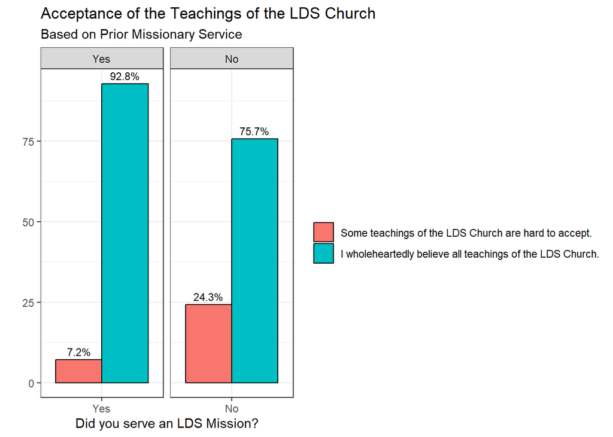

```r
#Count the data
count_mishconf <- mishconf %>% group_by(catmission, catconfidence) %>% summarize(count = n(), .groups = 'drop')

#Put the data into percent
percent_mishconf <- count_mishconf %>%
  group_by(catmission)%>%
  mutate(percent = count/sum(count) * 100)

#bar chart based on percents
ggplot(percent_mishconf, aes(x = catmission, y = percent, fill = catconfidence)) +
  geom_bar(stat = "identity", position = "dodge", color = "Black")+
  labs(
    x = "Did you serve an LDS Mission?",
    y = "",
    fill = "",
    title = "Acceptance of the Teachings of the LDS Church",
    subtitle = "Based on Prior Missionary Service")+
    geom_text(aes(label = sprintf("%.1f%%", percent)), position = position_dodge(width = 0.9), vjust = -0.5, color = "black", size = 3) +
  facet_wrap(~catmission, scales = "free_x")+
    theme_bw()
```

### Conclusions for this question:

Because the p-value is so low (1.781e-10), We can accept the alternative hypothesis and conclude that the results are not likely to be random. In other words, we have sufficient evidence to suggest that acceptance of the teachings of the LDS Church are not independent of prior mission service.

## Frequency of Prayer among Latter-day Saint’s based on Missionary Service

**Null hypothesis:** Frequency of prayer outside of Church Services is not affected by missionary service

**Alternative Hypothesis:** Frequency of prayer outside of church service is greater among former missionaries.

After initial analysis, a chi-squared test will not provide reliable results when comparing these variables. Thus, a fisher test will tell us if we accept the alternative hypothesis, and visualization will tell us how to interpret the results.

### Statistical Tests

```r
# Filter out NA and "Don't Know/Refused" to clean up results of test and presentation
prayfreq <- data_cat %>% filter(catmission != "", catmission != "Don't Know/Refused", catpray != "", catpray != "Don't know/Refused", pray != "", pray != "9") %>% select(catmission, catpray, pray)


#Perform the fisher test. The sample size was too large for the test, so simulation was turned on. to increase accuracy, the number of simulations was set to 10000. The p value was the same for greater, less, and two.sided, indicating that no matter the circumstance, the sample size was not random.
table(prayfreq$catmission, prayfreq$catpray) %>% fisher.test(simulate.p.value = TRUE, B = 10000) %>% print()
```

```
    Fisher's Exact Test for Count Data with simulated p-value (based on
    10000 replicates)

data:  .
p-value = 9.999e-05
alternative hypothesis: two.sided
```

### Visualize the Data

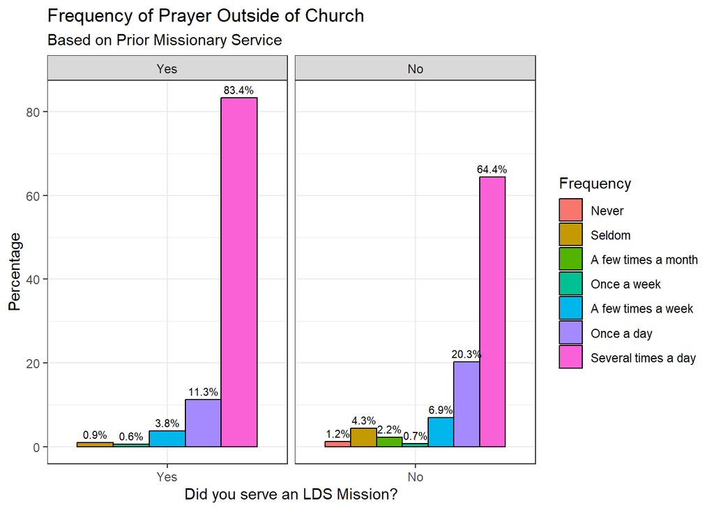

```r
#Calculate counts
count_prayfreq <- prayfreq %>%
  group_by(catmission, catpray) %>%
  summarize(count = n(), .groups = 'drop')

#Calculate percents
percent_prayfreq <- count_prayfreq %>% group_by(catmission) %>% mutate(percent = count / sum(count) * 100)


#Bar chart based on percents
ggplot(percent_prayfreq, aes(x = catmission, y = percent, fill = catpray)) +
  geom_bar(stat = "identity", position = "dodge", color = "black") +
  labs( x = "Did you serve an LDS Mission?",
        y = "Percentage",
        fill = "Frequency",
        title = "Frequency of Prayer Outside of Church",
        subtitle = "Based on Prior Missionary Service" ) +
  geom_text(aes(label = sprintf("%.1f%%", percent)), position = position_dodge(width = 0.9), vjust = -0.5, color = "black", size = 2.7) +
  facet_wrap(~catmission, scales = "free_x")+
  theme_bw()
```

### Conclusions for this question:

The p-value given from the fisher test was (9.999e-05), meaning we can accept the new hypothesis that whether or not one has served a mission and how frequently someone prayers are associated.

An analysis of the visual data shows that there is a noticeable difference in the frequency of prayer between those who have and haven’t served a mission. Because of the fisher test and the visualized data, for this question I conclude that the association is such that serving a mission increases prayer frequency.

## Frequency of Religious Service Attendance among Latter-day Saint’s based on Missionary Service

One of the results options was attending religious service ‘More than once a week’. The LDS Church holds one congregation-wide meting on Sundays, and also has various meetings and activities throughout the week. Religious services can be understood to encompass events that are church sponsored.

**Null hypothesis:** Frequency of religious service attendance is independent of past missionary service

**Alternative Hypothesis:** Frequency of religious service attendance is not independent of past missionary service

By performing a Chi-square test and analyzing the residuals, we can determine the probability of the relationship we observe being random chance, and the significance of the relationship.

### Statistical Tests

```r
# Filter out NA and "Don't Know/Refused" to clean up results of test and presentation
attendfreq <- data_cat %>% filter(
  catmission %in% c("Yes", "No"),
  catattend %in% c("Never","Seldom","A few times a year","Once or twice a month","Once a week","More than once a week"))


churchchi <- table(attendfreq$catmission, attendfreq$catattend) %>% chisq.test()
#can we trust the chi-square test?
churchchi$expected
```

```
          Never   Seldom A few times a year Once or twice a month Once a week
  Yes  6.634843 14.21752           17.37697              25.27559    153.5492
  No  14.365157 30.78248           37.62303              54.72441    332.4508

      More than once a week
  Yes              103.9459
  No               225.0541
```

```r
# yes
churchchi
```

```
    Pearson's Chi-squared test

data:  .
X-squared = 85.152, df = 5, p-value < 2.2e-16
```

```r
knitr::kable(churchchi$stdres)
```

|  | Never | Seldom | A few times a year | Once or twice a month | Once a week | More than once a week |
| --- | --- | --- | --- | --- | --- | --- |
| Yes | -2.198414 | -3.679397 | -4.585887 | -5.080264 | 1.546945 | 5.776525 |
| No | 2.198414 | 3.679397 | 4.585887 | 5.080264 | -1.546945 | -5.776525 |

### Visualize the Data

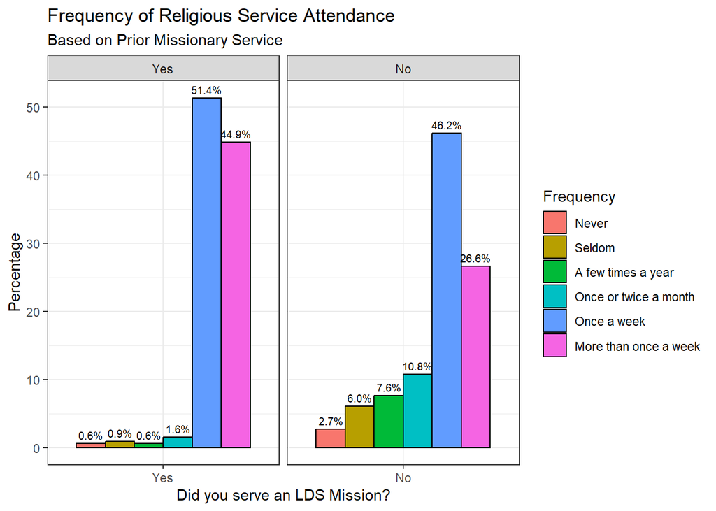

```r
#Calculate counts
count_attendfreq <- attendfreq %>%
  group_by(catmission, catattend) %>%
  summarize(count = n(), .groups = 'drop')

#Calculate percents
percent_attendfreq <- count_attendfreq %>% group_by(catmission) %>% mutate(percent = count / sum(count) * 100)

#Bar chart based on percents
ggplot(percent_attendfreq, aes(x = catmission, y = percent, fill = catattend)) +
  geom_bar(stat = "identity", position = "dodge", color = "black") +
  labs( x = "Did you serve an LDS Mission?",
        y = "Percentage",
        fill = "Frequency",
        title = "Frequency of Religious Service Attendance",
        subtitle = "Based on Prior Missionary Service" ) +
  geom_text(aes(label = sprintf("%.1f%%", percent)), position = position_dodge(width = 0.9), vjust = -0.5, color = "black", size = 2.7) +
  facet_wrap(~catmission, scales = "free_x")+
  theme_bw()
```

### Conclusions for this question

Because the p-value is very low (2e-16), we can reject the null hypothesis and conclude that there is a difference in church attendance among those who have and haven’t served missions.

An analysis of the residuals of the chi-squared test as well as the visualized data shows that church attendance among returned missionaries is higher than is mathematically predicted.

# Make Inferences

We have sufficient evidence to conclude that members who have served missions for the Church of Jesus Christ of Latter-day Saints are more likely to wholeheartedly accept the teachings of the church, pray more frequently, and attend religious services more frequently.

From my worldview as an active member of the LDS Church, I believe that greater attendance of religious services and more frequent prayer is indicative of a greater relationship and/or more faithfulness to God. Thus, from my perspective, serving a mission leads to a greater relationship with God. I acknowledge that this interpretation is subjective according to individually held worldview and beliefs.

# Conclusion (Take Action)

I have served an LDS mission myself, and will now be able to both subjectively and objectively relate certain impacts (which I perceive as benefits) that come form serving a mission.

As a friend and brother to several prospective missionaries, I can and will share my findings to logically show that serving a mission is beneficial to one who wants to be involved with God and the Church of Jesus Christ of Latter-day Saints.

As a prospective father, I now have statistical evidence and reasoning for why I should encourage my future children to serve a mission for this church.